# Lab5_NotTeamOne

David Orozco, Anderson Mun, Arie del Valle, Ethan Schacht, Ryan Tate

February 15, 2019

## Team Component

### Team Graph

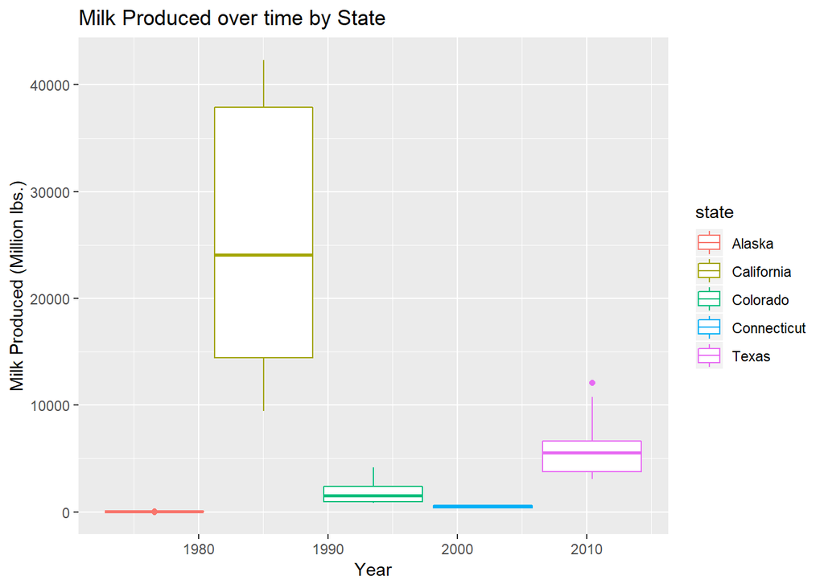

- In this lab, we thought using the dyplr functions and storing variables were most helpful in learning about the data. Using these functions helped us analyze the data, to find which state for exery year, produced the most milk. Storing variables helped us select and maniputalte specific data we wanted to show in our tables or in our graphs.

```
## # A tibble: 1 x 2
##    year  total
##   <dbl>  <dbl>
## 1  1975 115398
```

- 1975 is the year when the least milk was produced in the United States

```
## # A tibble: 1 x 2
##    year  total
##   <dbl>  <dbl>
## 1  2017 215466
```

- 2017 is the year when the most milk was produced in the United States

```
##         region        state year milk_produced milk_million
## 1      Pacific       Alaska 2017       3.0e+06            3
## 2    Northeast Rhode Island 2017       1.3e+07           13
## 3      Pacific       Hawaii 2017       3.9e+07           39
## 4 Delta States     Arkansas 2017       7.9e+07           79
## 5    Southeast      Alabama 2017       8.9e+07           89
```

- In 2017, the 5 states that produced the least milk were Alaska, Rhode Island, Hawaii, Arkansas, and Alabama in that order

```
##            region      state year milk_produced milk_million
## 1         Pacific California 2017    3.9798e+10        39798
## 2     Lake States  Wisconsin 2017    3.0320e+10        30320
## 3       Northeast   New York 2017    1.4912e+10        14912
## 4        Mountain      Idaho 2017    1.4627e+10        14627
## 5 Southern Plains      Texas 2017    1.2054e+10        12054
```

- In 2017, the 5 states that produced the most milk were Californaia Wisconsin, New York, Idaho and Texas in that order.

### Individual Component

#### Arie’s Data

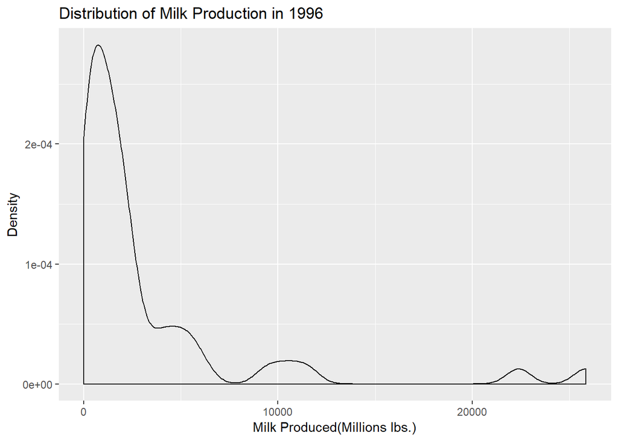

- The mean and median millions of pounds of milk are 3080.12 and 1480, respectively, as shown in the first data frame. California produces the most milk and Alaska produces the least amount of milk as shown in data frames two and three.

```
##   average med_1996 max_produced min_produced
## 1 3080.12     1480        25848           14
```

```
##    region      state year milk_produced milk_million
## 1 Pacific California 1996    2.5848e+10        25848
```

```
##    region  state year milk_produced milk_million
## 1 Pacific Alaska 1996       1.4e+07           14
```

#### Ryan’s Data

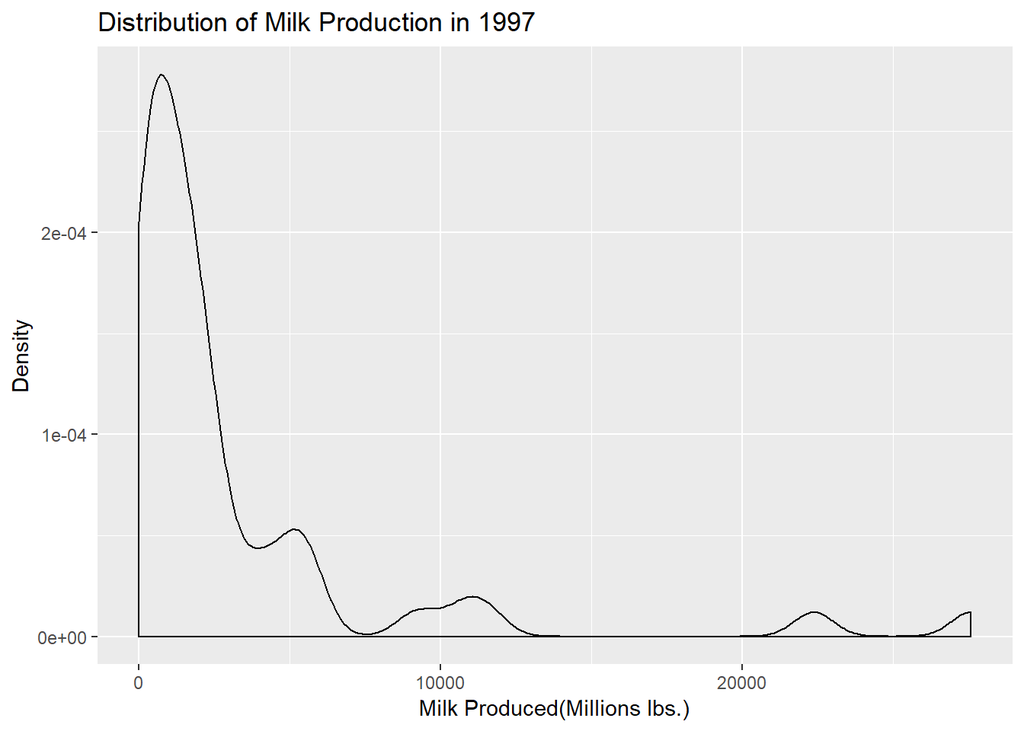

- The mean and median millions of pounds of milk are 3121.82 and 1436, respectively, as shown in the first data frame. California produces the most milk and Alaska produces the least amount of milk as shown in data frames two and three.

```
##   average med_1997 max_produced min_produced
## 1 3121.82     1436        27582           15
```

```
##    region      state year milk_produced milk_million
## 1 Pacific California 1997    2.7582e+10        27582
```

```
##    region  state year milk_produced milk_million
## 1 Pacific Alaska 1997       1.5e+07           15
```

#### Anderson’s Data

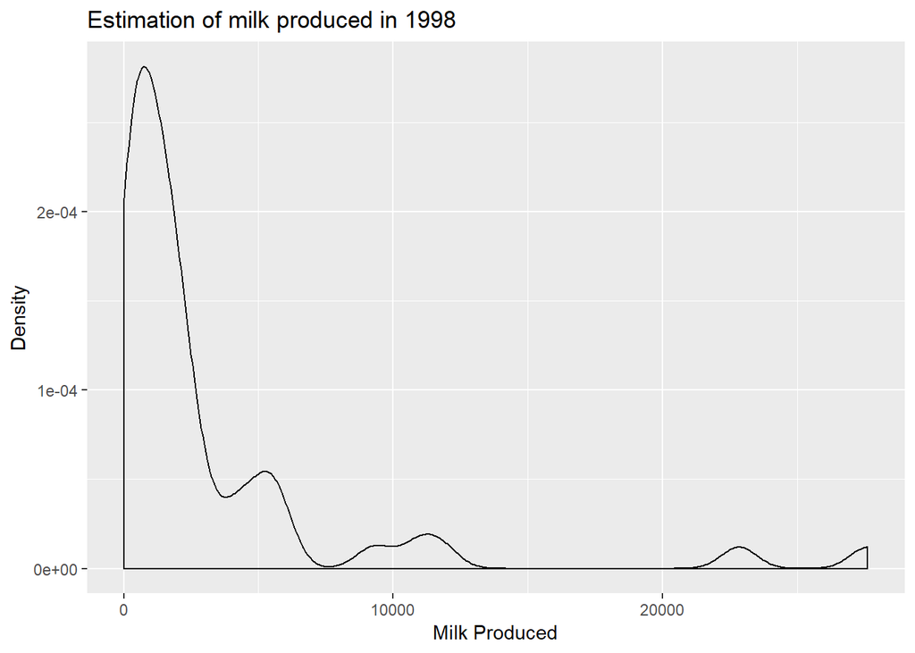

- The mean and median millions of pounds of milk are 3145.22 and 1411.5, respectively, as shown in the first data frame. California produces the most milk and Alaska produces the least amount of milk as shown in data frames two and three.

```
##   average med_1998 max_produced min_produced
## 1 3145.22   1411.5        27620           14
```

```
##    region      state year milk_produced milk_million
## 1 Pacific California 1998     2.762e+10        27620
```

```
##    region  state year milk_produced milk_million
## 1 Pacific Alaska 1998       1.4e+07           14
```

#### Ethan’s Data

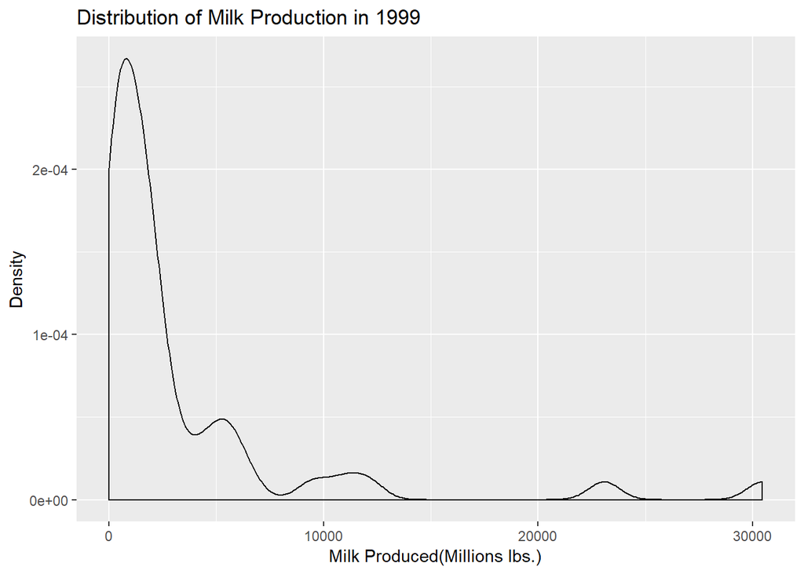

- The mean and median millions of pounds of milk are 3251.8 and 1418, respectively, as shown in the first data frame. California produces the most milk and Alaska produces the least amount of milk as shown in data frames two and three.

```
##   average med_1999 max_produced min_produced
## 1  3251.8     1418        30444           14
```

```
##    region      state year milk_produced milk_million
## 1 Pacific California 1999    3.0444e+10        30444
```

```
##    region  state year milk_produced milk_million
## 1 Pacific Alaska 1999       1.4e+07           14
```

#### David’s Data

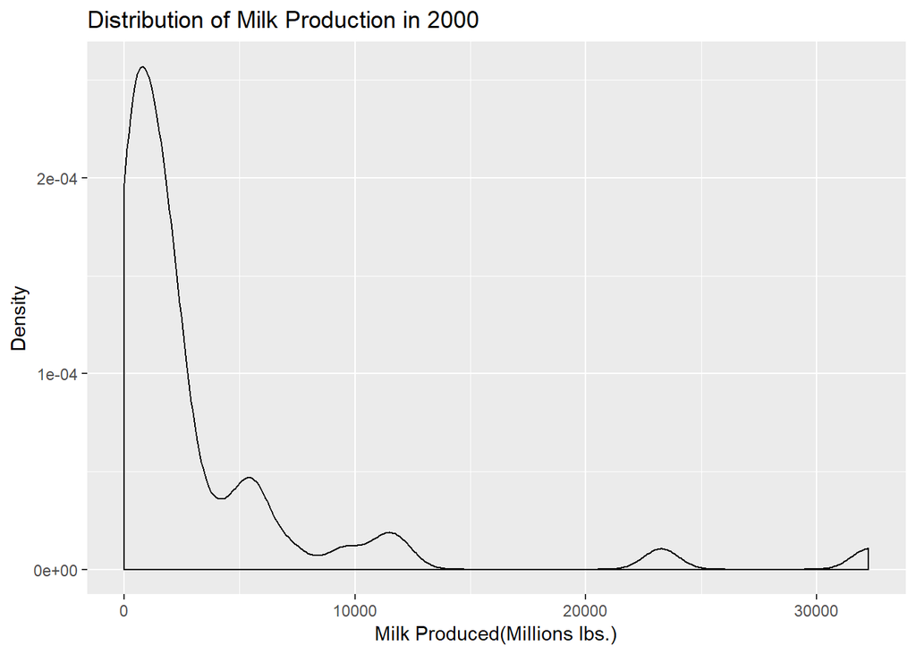

- The mean and median millions of pounds of milk are 3347.84 and 1453.5, respectively, as shown in the first data frame. California produces the most milk and Alaska produces the least amount of milk as shown in data frames two and three.

```
##   average med_2000 max_produced min_produced
## 1 3347.84   1453.5        32245           13
```

```
##    region      state year milk_produced milk_million
## 1 Pacific California 2000    3.2245e+10        32245
```

```
##    region  state year milk_produced milk_million
## 1 Pacific Alaska 2000       1.3e+07           13
```

#### Who Did What?

- Arie: Made team graph, typed what was helpful section, created repo
- Ryan: Found the 5 states that produced the least and most milk in 2017. Also found the year in which the most and least milk was produced.
- Anderson: Helped edit data set and created an indiviudal graph.
- Ethan: Helped edit data set and created an indiviudal graph. Edited merge conflicts and errors.
- David: Tibble creation for each year and formating doc. Added informative bullets under graphs and tables. Gave cookies to teammates.